# homework

Ziqiao Zhou

2022-12-08

# Hw1-2022-09-15

```r
library(latex2exp)
library(scales)
library(pander)
```

## Question

• Exercises 3.3, 3.7, 3.12, and 3.13 (pages 94-96, Statistical Computating with R).

## Answer

### 3.3

the probability inverse transformation F^(-1)(U) = b/((1-u)^(1/a))

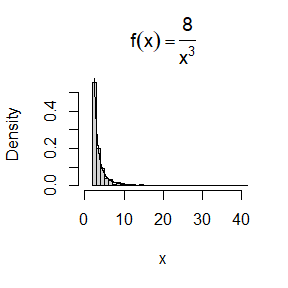

```r
n <- 1000
u <- runif(n)
#x <- b/((1-u)^(1/a)) F(x) = 1-(b/x)^a, x>=b>0, a>0
x <- 2/((1-u)^(1/2))
hist(x, prob = TRUE, xlim = c(0,40), breaks = 100, main = expression(f(x)==frac(8,x^3)))
y <- seq(2, 50, .01)
lines(y, 8/y^3)
```

### 3.7

```r
# acceptance-rejection method for Beta distribution
n <- 1e3; j<-k<-0; y <- numeric(n)
armethod_beta <- function(a,b){
  while (k < n) {
    u <- runif(1)
    j <- j + 1
    x <- runif(1) #random variate from g(.)
    if (x^(a-1) * (1-x)^(b-1) > u) {
      #we accept x
      k <- k + 1
      y[k] <- x
    }
  }
  return (list(j,y))
}
```

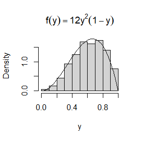

```r
# a=3,b=2
n <- 1e3; j<-k<-0; y <- numeric(n)
while (k < n) {
  u <- runif(1)
  j <- j + 1
  x <- runif(1) #random variate from g(.)
  if (x^2 * (1-x) > 16/9*u) {
    #we accept x
    k <- k + 1
    y[k] <- x
  }
}
hist(y, prob = TRUE, main = expression(f(y)==12*y^2*(1-y)))
z <- seq(0, 1, .01)
lines(z,dbeta(z,shape1=3,shape2=2))
```

### 3.12

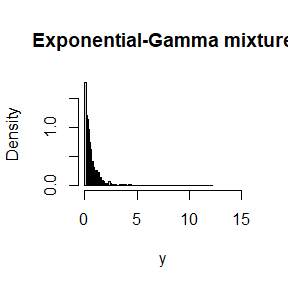

```r
n <- 1e3; r <- 4; beta <- 2
lambda <- rgamma(n, r, beta)
y <- rexp(n, lambda) # the length of lambda = n
hist(y, prob = TRUE, xlim = c(0,15), breaks = 100, main = "Exponential-Gamma mixture")
```

### 3.13

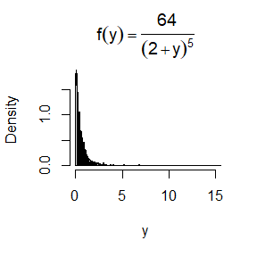

```r
n <- 1e3; r <- 4; beta <- 2
lambda <- rgamma(n, r, beta)
y <- rexp(n, lambda) # the length of lambda = n
hist(y, prob = TRUE, xlim = c(0,15), breaks = 100, main = expression(f(y)==frac(64,(2+y)^5)))
z <- seq(0, 50, .01)
lines(z, 64*(2+z)^(-5))
```

# Hw2-2022-09-23

## Question

• Question about fast sorting algorithm and exercises 5.6, 5.7(pages 149-151, Statistical Computing with R)

## Answer

### Hw2,1

```r
# the fast sorting algorithm
fast_sorting <- function(x){
  num = length(x)
  if (num==0||num==1){
    return(x)
  }
  else{
    a = x[1]
    y = x[-1]
    lower = y[y<a]
    upper = y[y>=a]
    return(c(fast_sorting(lower),a,fast_sorting(upper)))
  }
}

a = numeric(5)
t = c(10^4, 2*10^4, 4*10^4, 6*10^4, 8*10^4)
tn = t*log(t)
for (i in 1:5){
  sum_time = 0
  for (j in 1:100){
    test = sample(t[i])
    sum_time = sum_time + system.time(fast_sorting(test))[1]
  }
  a[i] = sum_time/100
}
a
```

```
## [1] 0.0177 0.0366 0.0768 0.1180 0.1671
```

```r
fit = lm(a~tn)
fit$coef
```

```
##  (Intercept)           tn
## 2.693482e-05 1.826974e-07
```

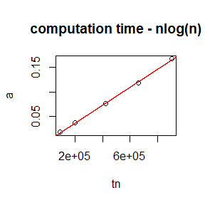

```r
plot(x=tn, y=a, main = "computation time - nlog(n)")
y <- seq(0, 10^6, 1)
lines(y, fit$coef[1]+fit$coef[2]*y, col="red")
```

It is a linear relationship between computation time and nlog(n).

### 5.6&5.7

```r
cov = exp(1)-(exp(1)-1)^2 # compute Cov
round(cov,5)
```

```
## [1] -0.23421
```

```r
var = 2*((exp(1)^2-1)/2-(exp(1)-1)^2) + 2*cov # compute Var
round(var,5)
```

```
## [1] 0.01565
```

```r
round(1-var/((exp(1)^2-1)/2-(exp(1)-1)^2),5) # the percent reduction
```

```
## [1] 0.93534
```

```r
# the calculated result
MC <- function(x, R = 10000, antithetic = FALSE) {
  u <- runif(R/2)
  if (antithetic) v <- 1 - u else v <- runif(R/2)
  u <- c(u, v)
  g <- exp(u*x)
  cdf <- mean(g)
  cdf
}
m <- 1000
MC1 <- MC2 <- numeric(m)
x <- 1
for (i in 1:m) {
  MC1[i] <- MC(x, R = 1000, antithetic = FALSE)
  MC2[i] <- MC(x, R = 1000, antithetic = TRUE)
}
c(mean(MC1),mean(MC2)) # theta's estimate：MC method and antithetic variate approach
```

```
## [1] 1.718026 1.718080
```

```r
round(c(sd(MC1)^2,sd(MC2)^2,1-sd(MC2)^2/sd(MC1)^2),7) # theta's variance：MC method and antithetic variate approach
```

```
## [1] 0.0002483 0.0000080 0.9676254
```

```r
# the theoretical value
var_antithetic = var/(2*m)
var_MC = ((exp(1)^2-1)/2-(exp(1)-1)^2)/m
round(c(var_antithetic,var_MC,1-var_antithetic/var_MC),7)
```

```
## [1] 0.0000078 0.0002420 0.9676701
```

The calculated result is close to the theoretical value.

# Hw3-2022-09-16

## Question

• Exercises 5.13, 5.15(pages 149-151, Statistical Computing with R).

## Answer

### 5.13

$g(x)=\frac{x^2}{\sqrt{2\pi}}e^{-\frac{1}{2}x^2}$

$f_1(x)=e^{1-x}$

$f_2(x)=\frac{1}{x^2}$

We’ll just call it $f_i$ for the method that uses $f_i$ as an importance function.

```r
g <- function(x){
  return (x^2/sqrt(2*pi)*exp(-x^2/2))
}
f1 <- function(x){
  return (exp(1-x))
}
f2 <- function(x){
  return (1/(x^2))
}

# The true value of the integral
I <- integrate(g,1,Inf)

m <- 1e6
set.seed(516)
u <- runif(m)

# the method that uses f1 as an importance function
x1 <- 1-log(1-u)
fg1 <- g(x1) / f1(x1)
I1_hat <- mean(fg1)
sd1 <- sd(fg1)

# the method that uses f2 as an importance function
x2 <- 1/(1-u)
fg2 <- g(x2) / f2(x2)
I2_hat <- mean(fg2)
sd2 <- sd(fg2)

round(c(I[[1]], I1_hat, I2_hat),5) # The true value of the integral and two estimations
```

```
## [1] 0.40063 0.40046 0.40038
```

```r
round(c(sd1,sd2),5) # stand error of f1 and f2
```

```
## [1] 0.15773 0.30560
```

The variance of $f_1$ is smaller.

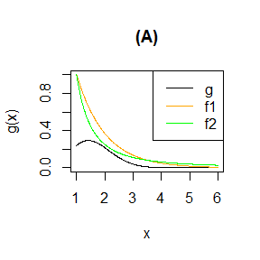

```r
x <- seq(1,6,0.01)
plot(x, g(x), col="black", type="l", ylim=c(0,1), main='(A)')
lines(x, f1(x), col="orange")
lines(x, f2(x), col="green")
legend("topright", col=c("black","orange","green"), lty=1, legend=c("g","f1","f2"))
```

We can see that in the plot, $\frac{g(x)}{f_1(x)}$ is smoother than $\frac{g(x)}{f_2(x)}$. That’s why the variance of $f_1$ is smaller.

### 5.15

```r
M <- 10000; k <- 5 # what if k is larger?
set.seed(516)
r <- M/k #replicates per stratum
N <- 50 #number of times to repeat the estimation
T2 <- numeric(k)
est <- matrix(0, N, 2)
g <- function(x)exp(-x)/(1+x^2)*(x>0)*(x<1)
p <- c(0,1/5,2/5,3/5,4/5,1)
q <- numeric(5)
for (i in 1:5){
  q[i] <- (1-exp(-1)) / (exp(-p[i]) - exp(-p[i+1]))
}
for (i in 1:N) {
  est[i,1] <- mean(g(runif(M)))
  for(j in 1:k){
    u <- runif(M) #f3, inverse transform method
    x <- - log(1 - u * (1 - exp(-1)))
    fg <- g(x) / q[j] / (exp(-x) / (1 - exp(-1)))
    T2[j] <- mean(fg)
  }
  est[i,2] <- T2[1]+T2[2]+T2[3]+T2[4]+T2[5]
}
round(c(0.5257801,apply(est,2,mean)),4)
```

```
## [1] 0.5258 0.5246 0.5248
```

```r
round(c(0.0970314,apply(est,2,sd)),5)
```

```
## [1] 0.09703 0.00216 0.00049
```

In this case, it can be seen that stratified sampling method is better than importance sampling method.

# Hw4-2022-10-09

## Question

• Exercises 6.4, 6.8(pages 180-181, Statistical Computing with R) and discussion.

## Answer

### 6.4

Suppose $Y=lnX$, it’s easy to know that the 95% confidence interval for the parameter $\mu_Y$ is

$\left[ \bar{Y} - \frac{S}{\sqrt{n}}t_{n-1}\left(\alpha/2\right) , \bar{Y} + \frac{S}{\sqrt{n}}t_{n-1}\left(\alpha/2\right)\right]$,

Where, $S^2=\frac{1}{n-1}\sum\limits_{i=1}^{n}\left(Y_i-\bar{Y}\right)^2$ is the sample variance.

Therefore, the 95% confidence interval for the parameter $\mu$ is

$\left[ exp\left\{ \bar{Y} - \frac{S}{\sqrt{n}}t_{n-1}\left(\alpha/2\right) \right\}, exp\left\{ \bar{Y} + \frac{S}{\sqrt{n}}t_{n-1}\left(\alpha/2\right) \right\} \right]$.

data generation

```r
lognormal_MC <- function(n, ml, sl){
  DCL <- numeric(1000);UCL <- numeric(1000)
  for (i in 1:1000){
    y <- rnorm(n, ml, sl)
    DCL[i] <- mean(y) - sd(y)/sqrt(n) * qt(0.975, df = n-1)
    UCL[i] <- mean(y) + sd(y)/sqrt(n) * qt(0.975, df = n-1)
  }
  D <- exp(mean(DCL));U <- exp(mean(UCL))
  rm(y);rm(DCL);rm(UCL) # clear memory
  return (c(D, U))
}
```

result reporting

```r
lognormal_MC(20, 0, 2) # example
```

```
## [1] 0.4010465 2.5211515
```

### 6.8

data generation

```r
count5test <- function(x, y) {
  X <- x - mean(x)
  Y <- y - mean(y)
  outx <- sum(X > max(Y)) + sum(X < min(Y))
  outy <- sum(Y > max(X)) + sum(Y < min(X))
  # return 1 (reject) or 0 (do not reject H0)
  rm(X) # clear memory
  rm(Y) # clear memory
  return(as.integer(max(c(outx, outy)) > 5))
}

Ftest <- function(x,y){
  return (as.integer(var.test(x,y,alternative = "two.sided",conf.level = 0.945)[[3]]<0.055))
}
```

data analysis

```r
sigma1 <- 1
sigma2 <- 1.5
compare_power <- function(m,n){
  sum_c = sum_f =0
  for (i in 1:m){
    x <- rnorm(n, 0, sigma1)
    y <- rnorm(n, 0, sigma2)
    sum_c = sum_c + count5test(x, y)
    sum_f = sum_f + Ftest(x, y)
  }
  power_c <- sum_c/m
  power_f <- sum_f/m
  rm(x) # clear memory
  rm(y) # clear memory
  return (c(power_c,power_f))
}
```

result reporting

```r
print("the power of the Count Five test, the power of F Test")
```

```
## [1] "the power of the Count Five test, the power of F Test"
```

```r
compare_power(1000,20) # Compare the power of the Count Five test and F test for small sample size(n=20).
```

```
## [1] 0.280 0.398
```

```r
compare_power(1000,100) # Compare the power of the Count Five test and F test for medium sample size(n=100).
```

```
## [1] 0.860 0.982
```

```r
compare_power(1000,1000) # Compare the power of the Count Five test and F test for large sample size(n=1000).
```

```
## [1] 0.997 1.000
```

It can be seen that the power of F test is greater than the power of the Count Five test for small, medium and large sample sizes.

### Discussion

#### QUESTION3.1

What is the corresponding hypothesis test problem?

#### ANSWER3.1

Let $Power_1$ express the power of the first method, $Power_2$ express the power of the second method.

Simulation results for the first method is 0.651.

Simulation results for the second method is 0.676.

$H_0:Power_1=Power_2,H1:Power1\neq Power2$.

#### QUESTION3.2

Which test can we use? Z-test, two-sample t-test, paired-t test or McNemar test? Why?

#### ANSWER3.2

McNemar test. McNemar is a non-parametric method for 10000 paired data, which is a 0-1 contingency table corresponding test (its content is a binomial distribution). In addition, Z-test, two-sample t-test and paired-t test are based on the normal distribution. So, we can’t use them in this situation.

The problem can be written as the 2*2 contingency table test.

Therefore:$H_0:n_{11}+n_{12}=n_{21}+n_{22}$.

The statistic of test is $X = \frac{(n_{12}-n_{21})^2}{n_{12}+n_{21}}$ , and it is a Chi-Squared distribution with $df=1$ under $H_0$.

#### QUESTION3.3

Please provide the least necessary information for hypothesis testing.

#### ANSWER3.3

From the information, we don’t know the results of 10,000 experiments. Only the specific results of 10,000 experiments are provided, we can get the contingency table. At present, we can’t say the powers are different at 0.05 level.

# Hw5-2022-10-14

## Question

• Exercises 7.4, 7.5, 7.A(pages 212-213, Statistical Computing with R).

## Answer

### 7.4

Assume $X_1,X_2,...,X_n i.i.d. \sim Exp(\lambda)$. It has the pdf $f(x,\lambda) = \lambda e^{- \lambda x}$.

The likelihood function is $L(\lambda;x_1, ... ,x_n) = \lambda ^ n e ^ {-n \overline x \lambda}$.

Then, $\frac{\partial ln(L)}{\partial{\lambda}} = \frac{n}{\lambda} - n \overline x$.

Let it $= 0$, we can get the MLE of $\lambda$ is $\hat\lambda = \frac{1}{\overline X}$.

data generation

```r
# bootstrap
x <- c(3, 5, 7, 18, 43, 85, 91, 98, 100, 130, 230, 487)
B <- 10000
set.seed(516)
lambdastar <- numeric(B)
lambda <- 1/mean(x)
for(b in 1:B){
  xstar <- sample(x, replace=TRUE)
  lambdastar[b] = 1 / mean(xstar)
}
```

result reporting

```r
c(lambda.bootest = mean(lambdastar), lambda.MLE = lambda, bias = mean(lambdastar) - lambda, se.boot = sd(lambdastar))
```

```
## lambda.bootest     lambda.MLE           bias        se.boot
##    0.010561175    0.009252120    0.001309054    0.004317109
```

```r
rm(lambdastar) # clear memory
```

### 7.5

data generation

```r
library(boot)
set.seed(516)
R <- 2000
skewness <- function(x,i){
  x_bar <- mean(x[i])
  x_bar
}
bo <- boot(data=x, statistic=skewness, R = R)
ci <- boot.ci(bo, type=c("norm", "basic", "perc", "bca"))
```

result reporting

```r
print(bo)
```

```
##
## ORDINARY NONPARAMETRIC BOOTSTRAP
##
##
## Call:
## boot(data = x, statistic = skewness, R = R)
##
##
## Bootstrap Statistics :
##     original    bias    std. error
## t1* 108.0833 0.5279583    37.67937
```

```r
print(ci)
```

```
## BOOTSTRAP CONFIDENCE INTERVAL CALCULATIONS
## Based on 2000 bootstrap replicates
##
## CALL :
## boot.ci(boot.out = bo, type = c("norm", "basic", "perc", "bca"))
##
## Intervals :
## Level      Normal              Basic
## 95%   ( 33.7, 181.4 )   ( 22.9, 168.8 )
##
## Level     Percentile            BCa
## 95%   ( 47.3, 193.3 )   ( 56.8, 227.4 )
## Calculations and Intervals on Original Scale
## Some BCa intervals may be unstable
```

```r
rm(bo) # clear memory
rm(ci) # clear memory
```

The CI calculated by the standard normal method is (33.7, 181.4). The length of interval is 147.7.

The CI calculated by the basic method is (22.9, 168.8). The length of interval is 145.9.

The CI calculated by the percentile method is (47.3, 193.3). The length of interval is 146.0.

The CI calculated by BCa method is (56.8, 227.4). The length of interval is 170.6.

Since the samples are not drawn from a normal distribution, the locations of these confidence intervals on the parameter space may not be the same. In addition, the distribution of X is not symmetric, which may also lead to different confidence intervals. BCa interval is a modified version of percentile CI, but it adjusts for both skewness and bias. So it’s different from the other three results.

### 7.A

data generation

```r
m <- 10000
ci.norm <- ci.basic <- ci.percent <- matrix(NA, m, 2)
skewness <- function(x,i){
  x_bar <- mean(x[i])
  x_bar
}
n <- 10
mu <- 0;sigma <- 1 # standard normal distribution
for(i in 1:m){
  s <- rnorm(n, mu, sigma)
  de <- boot(s, statistic=skewness, R=1000)
  ci <- boot.ci(de, type=c("norm","basic","perc"))
  ci.norm[i,] <- ci$norm[2:3]
  ci.basic[i,] <- ci$basic[4:5]
  ci.percent[i,] <- ci$percent[4:5]
}
```

result reporting

```r
t <- matrix(nrow=3, ncol=3)
rownames(t) <- c("normal","basic","perc")
colnames(t) <- c("coverage.prob", "missed.left", "missed.right")

t[,2] <- c(sum(mu<ci.norm[,1]),sum(mu<ci.basic[,1]),sum(mu<ci.percent[,1]))/m
t[,3] <- c(sum(mu>ci.norm[,2]),sum(mu>ci.basic[,2]),sum(mu>ci.percent[,2]))/m
t[,1] <- 1-t[,2]-t[,3]
t
```

```
##        coverage.prob missed.left missed.right
## normal        0.8977      0.0484       0.0539
## basic         0.8978      0.0482       0.0540
## perc          0.8961      0.0497       0.0542
```

```r
rm(list=ls()) # clear memory
```

# Hw6-2022-10-21

## Question

• Exercises 7.8, 7.11, 8.2(pages 212-213, 242, Statistical Computing with R).

## Answer

### 7.8

data generation

```r
data(scor, package = "bootstrap")
n <- nrow(scor)

sigma_hat <- cov(scor)
theta.hat <- eigen(sigma_hat)$values[1] / sum(eigen(sigma_hat)$values)

# compute the jackknife replicates, leave-one-out estimates
theta.jack <- numeric(n)
for (i in 1:n){
  s <- cov(scor[-i,])
  theta.jack[i] <- eigen(s)$values[1] / sum(eigen(s)$values)
}
```

result reporting

```r
sigma_hat
```

```
##          mec       vec       alg       ana       sta
## mec 305.7680 127.22257 101.57941 106.27273 117.40491
## vec 127.2226 172.84222  85.15726  94.67294  99.01202
## alg 101.5794  85.15726 112.88597 112.11338 121.87056
## ana 106.2727  94.67294 112.11338 220.38036 155.53553
## sta 117.4049  99.01202 121.87056 155.53553 297.75536
```

```r
theta.hat
```

```
## [1] 0.619115
```

```r
bias <- (n-1) * (mean(theta.jack) - theta.hat)
print(bias) #jackknife estimate of bias
```

```
## [1] 0.001069139
```

```r
se <- sqrt((n-1) * mean((theta.jack - mean(theta.jack))^2))
print(se)
```

```
## [1] 0.04955231
```

```r
#The jackknife estimate of standard error is 0.04955231. From the previous result for the bias, we have the estimated coefficient of variation
bias/se
```

```
## [1] 0.02157597
```

```r
rm(list=ls()) # clear memory
```

### 7.11

data generation

```r
library(DAAG,quietly=TRUE); attach(ironslag)
n <- length(magnetic)   #in DAAG ironslag
e1 <- e2 <- e3 <- e4 <- numeric(n*(n-1)/2)

# fit models on leave-two-out samples
i = 1
for (k in 1:(n-1)) {
  for (l in (k+1):n) {
    y <- magnetic[-c(k,l)]
    x <- chemical[-c(k,l)]

    J1 <- lm(y ~ x)
    yhat1k <- J1$coef[1] + J1$coef[2] * chemical[k]
    yhat1l <- J1$coef[1] + J1$coef[2] * chemical[l]
    e1[i] <- ((magnetic[k] - yhat1k)^2 + (magnetic[l] - yhat1l)^2)/2

    J2 <- lm(y ~ x + I(x^2))
    yhat2k <- J2$coef[1] + J2$coef[2] * chemical[k] + J2$coef[3] * chemical[k]^2
    yhat2l <- J2$coef[1] + J2$coef[2] * chemical[l] + J2$coef[3] * chemical[l]^2
    e2[i] <- ((magnetic[k] - yhat2k)^2 + (magnetic[l] - yhat2l)^2)/2

    J3 <- lm(log(y) ~ x)
    logyhat3k <- J3$coef[1] + J3$coef[2] * chemical[k]
    yhat3k <- exp(logyhat3k)
    logyhat3l <- J3$coef[1] + J3$coef[2] * chemical[l]
    yhat3l <- exp(logyhat3l)
    e3[i] <- ((magnetic[k] - yhat3k)^2 + (magnetic[l] - yhat3l)^2)/2

    J4 <- lm(log(y) ~ log(x))
    logyhat4k <- J4$coef[1] + J4$coef[2] * log(chemical[k])
    yhat4k <- exp(logyhat4k)
    logyhat4l <- J4$coef[1] + J4$coef[2] * log(chemical[l])
    yhat4l <- exp(logyhat4l)
    e4[i] <- ((magnetic[k] - yhat4k)^2 + (magnetic[l] - yhat4l)^2)/2

    i = i+1
  }
}
```

result reporting

```r
c(mean(e1), mean(e2), mean(e3), mean(e4))
```

```
## [1] 19.57227 17.87018 18.45491 20.46718
```

```r
rm(e1) # clear memory
rm(e2) # clear memory
rm(e3) # clear memory
rm(e4) # clear memory
```

According to the prediction error criterion, Model 2, the quadratic model, would be the best fit for the data.

### 8.2

data generation

```r
set.seed(210)
x <- rnorm(20,0,1)
y <- rnorm(20,0,1)
z <- c(x, y)
R <- 999
reps <- numeric(R)
cor0 <- cor(x, y, method = "spearman")

for (i in 1:999) {
  k <- sample(1:40, size = 20, replace = FALSE)
  x1 <- z[k];y1 <- z[-k]
  reps[i] <- cor(x1, y1, method = "spearman")
}
p <- mean(c(cor0, reps) >= cor0)
```

result reporting

```r
round(c(p,cor.test(x,y)$p.value),5)
```

```
## [1] 0.06000 0.08945
```

```r
rm(list=ls()) # clear memory
```

The p-value reported by cor.test is bigger than the achieved significance level of the permutation test.

# Hw7-2022-10-24

## Question

• Exercises 9.4, 9.7(pages 212-213, 242, Statistical Computing with R)

## Answer

### 9.4

data generation

```r
set.seed(516)
rw.Metropolis <- function(n, sigma, x0, N) {
  x <- numeric(N)
  x[1] <- x0
  u <- runif(N)
  k <- 0
  for (i in 2:N) {
    y <- rnorm(1, x[i-1], sigma)
      if (u[i] <= exp(abs(x[i-1])-abs(y)))
      x[i] <- y else {
        x[i] <- x[i-1]
        k <- k + 1
      }
  }
  return(list(x=x, k=k))
}
```

result reporting

```r
n <- 4 # degrees of freedom for target Student t dist.
N <- 2000
sigma <- c(.05, .5, 2, 8)

x0 <- 25
rw1 <- rw.Metropolis(n, sigma[1], x0, N)
rw2 <- rw.Metropolis(n, sigma[2], x0, N)
rw3 <- rw.Metropolis(n, sigma[3], x0, N)
rw4 <- rw.Metropolis(n, sigma[4], x0, N)
# number of candidate points rejected
# print(c(rw1$k, rw2$k, rw3$k, rw4$k))
print(round(c(1-rw1$k/N, 1-rw2$k/N, 1-rw3$k/N, 1-rw4$k/N),3)) # the acceptance rates of each chain
```

```
## [1] 0.982 0.829 0.520 0.201
```

```r
#par(mfrow=c(2,2))
#plot(rw1$x, type="l", xlab="sigma=0.05", ylab="X", ylim=range(rw1$x))
#plot(rw2$x, type="l", xlab="sigma=0.5", ylab="X", ylim=range(rw2$x))
#plot(rw3$x, type="l", xlab="sigma=2", ylab="X", ylim=range(rw3$x))
#plot(rw4$x, type="l", xlab="sigma=8", ylab="X", ylim=range(rw4$x))
```

data generation

```r
set.seed(516)

Gelman.Rubin <- function(psi) {
  # psi[i,j] is the statistic psi(X[i,1:j])
  # for chain in i-th row of X
  psi <- as.matrix(psi)
  n <- ncol(psi)
  k <- nrow(psi)
  psi.means <- rowMeans(psi) #row means
  B <- n * var(psi.means) #between variance est.
  psi.w <- apply(psi, 1, "var") #within variances
  W <- mean(psi.w) #within est.
  v.hat <- W*(n-1)/n + (B/n) #upper variance est.
  r.hat <- v.hat / W #G-R statistic
  return(r.hat)
}

normal.chain <- function(sigma, N, X1) {
  # generates a Metropolis chain for Normal(0,1)
  # with Normal(X[t], sigma) proposal distribution
  # and starting value X1
  x <- rep(0, N)
  x[1] <- X1
  u <- runif(N)

  for (i in 2:N) {
    y <- rnorm(1, x[i-1], sigma)
      if (u[i] <= exp(abs(x[i-1])-abs(y)))
      x[i] <- y else {
        x[i] <- x[i-1]
      }
  }
  return(x)
}

# sigma <- 2 #parameter of proposal distribution
k <- 4 # number of chains to generate
n <- 15000 # length of chains
b <- 1000 # burn-in length

# choose overdispersed initial values
x0 <- c(-10, -5, 5, 10)

sigma.chain <- function(sigma) {
# generate the chains
X <- matrix(0, nrow=k, ncol=n)
for (i in 1:k)
  X[i, ] <- normal.chain(sigma, n, x0[i])

# trace plots
plot(1:n,X[1,],type="l")
lines(1:n,X[2,],type="l",col=2)
lines(1:n,X[3,],type="l",col=3)
lines(1:n,X[4,],type="l",col=4)

# compute diagnostic statistics
psi <- t(apply(X, 1, cumsum))
for (i in 1:nrow(psi))
  psi[i,] <- psi[i,] / (1:ncol(psi))
print(Gelman.Rubin(psi))

# plot psi for the four chains
par(mfrow=c(2,2))
for (i in 1:k)
  plot(psi[i, (b+1):n], type="l", xlab=i, ylab=bquote(psi))
par(mfrow=c(1,1)) # restore default

# plot the sequence of R-hat statistics
rhat <- rep(0, n)
for (j in (b+1):n)
  rhat[j] <- Gelman.Rubin(psi[,1:j])
plot(rhat[(b+1):n], type="l", xlab="", ylab="R")
abline(h=1.2, lty=2)
}
```

result reporting

```r
#sigma.chain(.05)
#sigma.chain(.5)
#sigma.chain(2)
#sigma.chain(8)

rm(list=ls()) # clear memory
```

### 9.7

data generation

```r
set.seed(516)
# initialize constants and parameters
N <- 10000 # length of chain
burn <- 1000 # burn-in length
X <- matrix(0, N, 2) # the chain, a bivariate sample

rho <- 0.9 # correlation
mu1 <- 0
mu2 <- 0
sigma1 <- 1
sigma2 <- 1
s1 <- sqrt(1-rho^2)*sigma1
s2 <- sqrt(1-rho^2)*sigma2

###### generate the chain #####

X[1, ] <- c(mu1, mu2) # initialize
for (i in 2:N) {
  x2 <- X[i-1, 2]
  m1 <- mu1 + rho * (x2 - mu2) * sigma1/sigma2
  X[i, 1] <- rnorm(1, m1, s1)
  x1 <- X[i, 1]
  m2 <- mu2 + rho * (x1 - mu1) * sigma2/sigma1
  X[i, 2] <- rnorm(1, m2, s2)
}

Y <- t(X)
b <- burn + 1
x <- X[b:N, ]

Gelman.Rubin <- function(psi) {
  # psi[i,j] is the statistic psi(X[i,1:j])
  # for chain in i-th row of X
  psi <- as.matrix(psi)
  n <- ncol(psi)
  k <- nrow(psi)
  psi.means <- rowMeans(psi) #row means
  B <- n * var(psi.means) #between variance est.
  psi.w <- apply(psi, 1, "var") #within variances
  W <- mean(psi.w) #within est.
  v.hat <- W*(n-1)/n + (B/n) #upper variance est.
  r.hat <- v.hat / W #G-R statistic
  return(r.hat)
}
```

result reporting

```r
# compare sample statistics to parameters
cor(x)
```

```
##           [,1]      [,2]
## [1,] 1.0000000 0.8981412
## [2,] 0.8981412 1.0000000
```

```r
cat('Means: ',round(colMeans(x),3),'\n')
```

```
## Means:  -0.044 -0.048
```

```r
cat('Standard errors: ',round(apply(x,2,sd),3),'\n')
```

```
## Standard errors:  0.988 0.991
```

```r
cat('Correlation coefficients: ', round(cor(x[,1],x[,2]),3),'\n')
```

```
## Correlation coefficients:  0.898
```

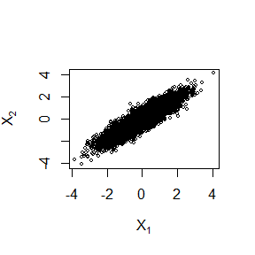

```r
plot(x, main="", cex=.5, xlab=bquote(X[1]), ylab=bquote(X[2]), ylim=range(x[,2]))
```

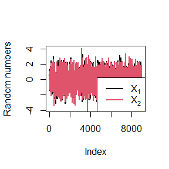

```r
plot(x[,1], type='l', col=1, lwd=2, xlab='Index', ylab='Random numbers')
lines(x[,2], col=2, lwd=2)
legend('bottomright', c(expression(X[1]),expression(X[2])), col=1:2, lwd=2)
```

```r
L <- lm(x[,2] ~ x[,1])
L
```

```
##
## Call:
## lm(formula = x[, 2] ~ x[, 1])
##
## Coefficients:
## (Intercept)       x[, 1]
##   -0.008759     0.901355
```

```r
summary(L)
```

```
##
## Call:
## lm(formula = x[, 2] ~ x[, 1])
##
## Residuals:
##      Min       1Q   Median       3Q      Max
## -1.70536 -0.29345 -0.00029  0.29302  1.95050
##
## Coefficients:
##              Estimate Std. Error t value Pr(>|t|)
## (Intercept) -0.008759   0.004599  -1.904   0.0569 .
## x[, 1]       0.901355   0.004652 193.756   <2e-16 ***
## ---
## Signif. codes:  0 '***' 0.001 '**' 0.01 '*' 0.05 '.' 0.1 ' ' 1
##
## Residual standard error: 0.4359 on 8998 degrees of freedom
## Multiple R-squared:  0.8067, Adjusted R-squared:  0.8066
## F-statistic: 3.754e+04 on 1 and 8998 DF,  p-value: < 2.2e-16
```

```r
#n <- 10000
#b <- 1000

# compute diagnostic statistics
#psi <- t(apply(Y, 1, cumsum))
#for (i in 1:nrow(psi))
#  psi[i,] <- psi[i,] / (1:ncol(psi))
#print(Gelman.Rubin(psi))

# plot psi for the four chains
#par(mfrow=c(2,2))
#for (i in 1:2)
#  plot(psi[i, (b+1):n], type="l", xlab=i, ylab=bquote(psi))
#par(mfrow=c(1,1)) # restore default

# plot the sequence of R-hat statistics
#rhat <- rep(0, n)
#for (j in (b+1):n)
#  rhat[j] <- Gelman.Rubin(psi[,1:j])
#plot(rhat[(b+1):n], type="l", xlab="", ylab="R")
#abline(h=1.2, lty=2)

rm(list=ls()) # clear memory
```

# Hw8-2022-11-04

## Question

• Hw8.1&8.2

## Answer

### Hw8.1

data generation

```r
#Model <- function(alpha, beta, gamma, N){
#  x <- rnorm(N, 0, 1)
#  e_M <- rnorm(N, 0, 1)
#  e_Y <- rnorm(N, 0, 1)
#  m <- alpha*x + e_M
#  y <- beta*m + gamma*x + e_Y
#  return(data.frame(x, m, y))
#}
#
#t <- function(x, m, y){
#  data <- data.frame(x, m, y)
#  Model_M <- lm(m~x, data=data)
#  Model_Y <- lm(y~m+x, data=data)
#  t <- Model_M$coef[2]*Model_Y$coef[2]/sqrt(Model_M$coef[2]^2*(summary(Model_M)$coefficients[2,2])^2+Model_Y$coef[2]^2*(summary(Model_Y)$coefficients[2,2])^2)
#  return(as.numeric(t))
#}

#Permutation_Test_1 <- function(data){
#  N <- 10; B <- 499
#  reps <- numeric(B)
#  for (i in 1:B) {
#    k <- sample(1:N, size = N, replace = FALSE)
#    x <- data[k, 1]
#    reps[i] <- t(x, data$m, data$y)
#  }
#  p_hat <- (sum(abs(reps)>abs(t(data$x, data$m, data$y)))+1)/(1+B)
#  return(p_hat<0.05)
#}
#
#Permutation_Test_2 <- function(data){
#  N <- 10; B <- 499
#  reps <- numeric(B)
#  for (i in 1:B) {
#    k <- sample(1:N, size = N, replace = FALSE)
#    y <- data[k, 3]
#    reps[i] <- t(data$x, data$m, y)
#  }
#  p_hat <- (sum(abs(reps)>abs(t(data$x, data$m, data$y)))+1)/(1+B)
#  return(p_hat<0.05)
#}
#
#Permutation_Test_3 <- function(data){
#  N <- 10; B <- 499
#  reps <- numeric(B)
#  for (i in 1:B) {
#    k <- sample(1:N, size = N, replace = FALSE)
#    m <- data[k, 2]
#    reps[i] <- t(data$x, m, data$y)
#  }
#  p_hat <- (sum(abs(reps)>abs(t(data$x, data$m, data$y)))+1)/(1+B)
#  return(p_hat<0.05)
#}
#
#simulation <- function(alpha, beta, gamma=1, N=10){
#  Type_1_error <- matrix(0, nrow = 3, ncol = 200)
#  for (i in 1:200) {
#    data <- Model(alpha, beta, gamma, N)
#    Type_1_error[1,i] <- Permutation_Test_1(data)
#    Type_1_error[2,i] <- Permutation_Test_2(data)
#    Type_1_error[3,i] <- Permutation_Test_3(data)
#  }
#  return(c(mean(Type_1_error[1,]),mean(Type_1_error[2,]),mean(Type_1_error[3,])))
#}
```

result reporting

```r
#set.seed(516)
#simulation1 <- simulation(alpha=0, beta=0)
#simulation2 <- simulation(alpha=0, beta=1)
#simulation3 <- simulation(alpha=1, beta=0)
#Permutation_Test <- data.frame(Model1=simulation1, Model2=simulation2, Model3=simulation3)
#row.names(Permutation_Test) <- c("Permutation_Test_1", "Permutation_Test_2", "Permutation_Test_3")
#Permutation_Test
#
#rm(list=ls()) # clear memory
```

### Hw8.2

data generation

```r
gfo <- function(N, b1, b2, b3, f0, x1, x2, x3){
  g <- function(alpha){
    tmp <- exp(-alpha-b1*x1-b2*x2-b3*x3)
    p <- 1/(1+tmp)
    mean(p) - f0
  }
}

alpha_estimation <- function(N, b1, b2, b3, f0){
  x1 <- rpois(N,1); x2 <- rexp(N); x3 <- sample(0:1, N, replace=TRUE)

  solution <- uniroot(gfo(N, b1, b2, b3, f0, x1, x2, x3),c(-15,5))
  round(unlist(solution),5)[1:3]

  alpha <- solution$root

  tmp <- exp(-alpha-b1*x1-b2*x2-b3*x3)
  p <- 1/(1+tmp)
  d <- rbinom(N,1,p)
  mean(d) # estimation of alpha
}
```

result reporting

```r
set.seed(516)
N <- 1e6; b1 <- 0; b2 <- 1; b3 <- -1
alpha_estimation(N, b1, b2, b3, 0.1)
```

```
## [1] 0.099842
```

```r
alpha_estimation(N, b1, b2, b3, 0.01)
```

```
## [1] 0.010103
```

```r
alpha_estimation(N, b1, b2, b3, 0.001)
```

```
## [1] 0.001009
```

```r
alpha_estimation(N, b1, b2, b3, 0.0001)
```

```
## [1] 9.6e-05
```

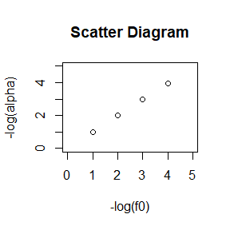

```r
x = -log(c(0.1, 0.01, 0.001, 0.0001), 10)
y = -log(c(alpha_estimation(N, b1, b2, b3, 0.1), alpha_estimation(N, b1, b2, b3, 0.01),
           alpha_estimation(N, b1, b2, b3, 0.001), alpha_estimation(N, b1, b2, b3, 0.0001)), 10)
plot(x, y, type="p", main = "Scatter Diagram", xlab = "-log(f0)", ylab = "-log(alpha)", xlim = c(0,5), ylim = c(0,5))
```

```r
rm(list=ls()) # clear memory
```

# Hw9-2022-11-11

## Question

• One class work, 2.1.3 Exercise 4, 5; 2.3.1 Exercise 1, 2; 2.4.5 Exercise 1, 2, 3 (Advanced in R)

## Answer

### Class work

```r
# maximizing likelihood function
u <- c(11,8,27,13,16,0,23,10,24,2)
v <- c(12,9,28,14,17,1,24,11,25,3)

max_likelihood <- function(lam){
  return(sum((v*exp(-lam*v)-u*exp(-lam*u))/(exp(-lam*u)-exp(-lam*v))))
}

round(uniroot(max_likelihood, c(0, 10))$root, 5)
```

```
## [1] 0.07197
```

```r
# EM algorithm
lam <- 2
i <- 0
eps <- 1e-3
lam1 <- 1
while(1){
  lam1 <- lam1 - max_likelihood(lam)/length(u)
  if (abs(1/lam1 - lam) < eps) break
  i <- i+1
  lam <- 1/lam1
}
round(c(iter = i, lambda = lam), 5)
```

```
##    iter  lambda
## 2.00000 0.07197
```

```r
rm(list=ls()) # clear memory
```

We can see that the estimates for both maximizing likelihood function and EM algorithm are 0.07197. So EM estimate equals to MLE.

### 2.1.3

Vectors in R are divided into two categories, atomic and list. The difference is that the former must have the same element type, and the latter can be different. The former is represented by vector and matrice, and the latter by list and data frame.

Since they are both vectors, ‘is.vector()’ cannot distinguish between vectors and lists. Of course, we can’t convert a list into a vector using ‘as.vector()’. If we want to convert a list to a vector, we should use ‘unlist()’.

```r
unlist(list(list(1, 2), c(3, 4)))
```

```
## [1] 1 2 3 4
```

```r
as.vector(list(list(1, 2), c(3, 4)))
```

```
## [[1]]
## [[1]][[1]]
## [1] 1
##
## [[1]][[2]]
## [1] 2
##
##
## [[2]]
## [1] 3 4
```

```r
1 == "1"
```

```
## [1] TRUE
```

If the two arguments are atomic vectors of different types, one is coerced to the type of the other, the (decreasing) order of precedence being character, complex, numeric, integer, logical and raw. So 1 == “1” is true.

```r
-1 < FALSE
```

```
## [1] TRUE
```

```r
0 == FALSE
```

```
## [1] TRUE
```

In numerical judgment, ‘FALSE’ stands for 0. This is why -1 < FALSE is true.

```r
"one" < 2
```

```
## [1] FALSE
```

```r
"one" > 2
```

```
## [1] TRUE
```

If the two arguments are atomic vectors of different types, one is coerced to the type of the other, the (decreasing) order of precedence being character, complex, numeric, integer, logical and raw.

In this case, character takes precedence over integer. So “one” < 2 is false.

### 2.3.1

1. NULL. Because ‘dim’ is used on matrix, array, or data frame.

```r
dim(c(1,2,3,4,5,6))
```

[output not shown]

2. TRUE

```r
x <- matrix(c(1:12), nrow = 4, byrow = TRUE)

is.matrix(x)
```

```
## [1] TRUE
```

```r
is.array(x)
```

```
## [1] TRUE
```

### 2.4.5

1. Names, dimensions, class.
2. Its elements will be coerced into a same type, following the rule: logical < integer < double < character.

```r
d <- data.frame(name=c("Zhang San", "Li Si", "Wang Wu"), age=c(30, 35, 28),
     height=c(182, 164, 175))
d
```

```
##        name age height
## 1 Zhang San  30    182
## 2     Li Si  35    164
## 3   Wang Wu  28    175
```

```r
as.matrix(d)
```

```
##      name        age  height
## [1,] "Zhang San" "30" "182"
## [2,] "Li Si"     "35" "164"
## [3,] "Wang Wu"   "28" "175"
```

```r
# a data frame with 0 rows
# method 1
test1=data.frame(col1=character(0), col2=numeric(0), col3=logical(0))
test1
```

```
## [1] col1 col2 col3
## <0 rows> (or 0-length row.names)
```

```r
str(test1)
```

```
## 'data.frame':    0 obs. of  3 variables:
##  $ col1: chr
##  $ col2: num
##  $ col3: logi
```

```r
# method 2
test2=matrix(data=NA, nrow=0, ncol=3)
test2=as.data.frame(test2)
colnames(test2)=c("col1", "col2", "col3")
test2
```

```
## [1] col1 col2 col3
## <0 rows> (or 0-length row.names)
```

```r
str(test2)
```

```
## 'data.frame':    0 obs. of  3 variables:
##  $ col1: logi
##  $ col2: logi
##  $ col3: logi
```

```r
# a data frame with 0 cols
# method 1
test3=matrix(data=NA, nrow=3, ncol=0)
test3=as.data.frame(test3)
rownames(test3)=c("row1", "row2", "row3")
test3
```

```
## data frame with 0 columns and 3 rows
```

```r
str(test3)
```

```
## 'data.frame':    3 obs. of  0 variables
```

```r
# a data frame with 0 rows and 0 cols
# method 1
data.frame()
```

```
## data frame with 0 columns and 0 rows
```

```r
rm(list=ls()) # clear memory
```

# Hw10-2022-11-18

## Question

• Exercises 2 on page 204,Exercises 1 on page 213 (Advanced R) and Gibbs Sampler.

## Answer

### Exercises 2

```r
#library(tidyverse)
scale01 <- function(x) {
  rng <- range(x, na.rm = TRUE)
  (x - rng[1]) / (rng[2] - rng[1])
}
d <- data.frame(col1=c(2, 1, 0), col2=c(5, 1, 6), col3=c(4, 2, 3))
scale01_apply <- apply(d, 2, scale01)
scale01_apply
```

```
##      col1 col2 col3
## [1,]  1.0  0.8  1.0
## [2,]  0.5  0.0  0.0
## [3,]  0.0  1.0  0.5
```

```r
d2 <- data.frame(col1=c(2, 1, 0), col2=c(5, 1, 6), col3=c("a","b","c"))
#lapply(select_if(d2,is.numeric), scale01)
```

```r
rm(list=ls()) # clear memory
```

### Exercises 1

```r
d_a <- data.frame(col1=c(1, 2, 3), col2=c(1, 3, 5), col3=c(1, 4, 7))
d_a
```

```
##   col1 col2 col3
## 1    1    1    1
## 2    2    3    4
## 3    3    5    7
```

```r
sd_vapply <- vapply(d_a, sd, numeric(1))
sd_vapply
```

```
## col1 col2 col3
##    1    2    3
```

```r
d_b <- data.frame(name=c("Zhang San", "Li Si", "Wang Wu"), age=c(30, 35, 28),
     height=c(182, 164, 175))
d_b
```

```
##        name age height
## 1 Zhang San  30    182
## 2     Li Si  35    164
## 3   Wang Wu  28    175
```

```r
vapply(d_b[,which(vapply(
  d_b,is.numeric,FUN.VALUE = logical(1)))]
  , sd, FUN.VALUE = numeric(1))
```

```
##      age   height
## 3.605551 9.073772
```

```r
rm(list=ls()) # clear memory
```

### Gibbs Sampler

data generation

```r
set.seed(516)
gibbsR <- function(mu1, mu2, sigma1, sigma2, rho, N, burn){
  X <- matrix(0, N, 2)
  s1 <- sqrt(1-rho^2)*sigma1
  s2 <- sqrt(1-rho^2)*sigma2
  X[1, ] <- c(mu1, mu2) # initialize
  for (i in 2:N) {
    x2 <- X[i-1, 2]
    m1 <- mu1 + rho * (x2 - mu2) * sigma1/sigma2
    X[i, 1] <- rnorm(1, m1, s1)
    x1 <- X[i, 1]
    m2 <- mu2 + rho * (x1 - mu1) * sigma2/sigma1
    X[i, 2] <- rnorm(1, m2, s2)
  }
  Y <- t(X)
  b <- burn + 1
  x <- X[b:N, ]
  return(x)
}
```

result reporting

```r
library(Rcpp)
# Can create source file in Rstudio
sourceCpp('../src/gibbsC.cpp')
library(microbenchmark)
ts <- microbenchmark(gibbsR=gibbsR(0, 0, 1, 1, 0.9, 10000, 1000),
                     gibbscpp=gibbsC(0, 0, 1, 1, 0.9, 10000, 1000))
summary(ts)[,c(1,3,5,6)]
```

```
##       expr       lq   median      uq
## 1   gibbsR 37.59690 40.63655 45.1813
## 2 gibbscpp  2.21515  2.25810  2.4078
```

Function gibbsC is much quicker than gibbsR.

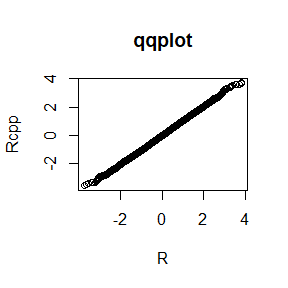

```r
qqplot(gibbsR(0, 0, 1, 1, 0.9, 10000, 1000), gibbsC(0, 0, 1, 1, 0.9, 10000, 1000), main="qqplot", xlab='R', ylab='Rcpp')
```

```r
rm(list=ls()) # clear memory
```

**Thank you for your review.**